# IISER Advanced Bioacoustics Workshop - BirdNET thresholding for detection data

February 2026

## Code source

*This code has been modified from supplementary material included in:*

Wood, C.M., Kahl, S. Guidelines for appropriate use of BirdNET scores and other detector outputs. J Ornithol 165, 777–782 (2024). https://doi.org/10.1007/s10336-024-02144-5

*Important notes:*

- BirdNET confidence scores are not probabilistic, although they are between 0 and 1
- confidence scores (and thresholds produced below) are not transferable among species or recording settings

## Code purpose

We use logistic regression to create probabilistic BirdNET score thresholds for compiling a species detection history.

## 1) Manually validate BirdNET predictions

Randomly select samples from the BirdNET output and manually validate whether BirdNET correctly identified the species. For example, you may generate 100 samples from confidence scores ranging from 0.1 to 1.0 and 100 samples from confidence scores ranging from 0.95 to 1.0. That is what we have done here for the Phainopepla (phai) bird dataset. More or fewer samples may be needed to encompass the full variation in any given dataset. You could also set a lower bound than 0.95 (e.g., 0.90) for the higher-confidence samples.

## 2) Read the validation results into R

```r
#read data
data = read.csv('phai_validation.csv')
#transform confidence scores to logit scale (an unbounded metric)
data$logit=log(data$confidence/(1-data$confidence))
#we do this becasue the highest confidence scores tend to be compressed in a 0-1 scale
head(data)
```

```
##                                         full_id confidence correct    logit
## 1 951_02_G080_V1_C5992_U2_20210705_200001Z.flac      0.951       1 2.965694
## 2  952_01_G015_V1_C315_U1_20210522_070104Z.flac      0.952       1 2.987364
## 3 952_01_G087_V1_C6530_U1_20210630_060002Z.flac      0.952       1 2.987364
## 4 952_03_G090_V1_C6627_U1_20210608_060002Z.flac      0.952       1 2.987364
## 5 953_02_G089_V1_C6629_U1_20210606_190000Z.flac      0.953       1 3.009467
## 6 953_03_G089_V1_C6629_U1_20210606_190000Z.flac      0.953       1 3.009467
```

```r
range(data$logit)
```

```
## [1] -2.164327  6.906755
```

```r
range(data$confidence)
```

```
## [1] 0.103 0.999
```

*Data column descriptions:*

**full_id** = the audio clip

**confidence** = a unitless, numeric expression of BirdNET’s “confidence” in its prediction, scaled to the range [0–1]

**correct** = whether the audio clip was correct n identifying the species (1) or was incorrect (0), by manual validation

## 2) Fit logistic regression models

We will fit three logistic regression models to the data, a null model which assumes no relationship between BirdNET score and prediction outcome, one relating confidence score to prediction outcome, and one relating the logit score to prediction outcome. Then we’ll see which model has the most support from the data, as evidenced by a lower AIC score.

```r
  #fit models
  null.model=glm(correct~1, data, family = 'binomial')
  conf.model=glm(correct~confidence, data, family = 'binomial')
  logit.model=glm(correct~logit, data, family = 'binomial')

  #create AIC table
  aic.table = AIC(null.model, conf.model, logit.model)
  aic.table[order(aic.table$AIC, decreasing=F), ]
```

```
##             df       AIC
## logit.model  2  71.25714
## conf.model   2  73.76833
## null.model   1 148.77000
```

## 3) Calculate thresholds and plot the results

It can be helpful to visualize the logistic curve and the results. We can solve the logistic equation for the desired probability thresholds and plot them as vertical lines on the graphs. First, we need to generate sample data and solve for those thresholds.

The thresholds are the core output of this whole process. They tell you what BirdNET score (confidence or logit) yields a given probability of achieving a correct prediction.

```r
  #generate a prediction range from the min and max confidence score
  prediction.range.conf=seq(0,1,.001)
  #generate a prediction range from the min and max logit score
  prediction.range.logit=seq(-3,7,.1)

  #predict whether a species detection is correct based on the confidence model
  predictions.conf=predict(conf.model, list(confidence=prediction.range.conf), type='r')
  #predict whether a species detection is correct based on the logit model
  predictions.logit=predict(logit.model, list(logit=prediction.range.logit), type='r')

  # solve for the desired thresholds for pr(true positive): .90, 0.95, and 0.99

  #confidence score model
  c.intercept = conf.model$coefficients[1]
  c.beta = conf.model$coefficients[2]
  cutoff90.c=(log(.90/(1-.90))-c.intercept)/c.beta; cutoff90.c
```

```
## (Intercept)
##    0.591287
```

```r
  cutoff95.c=(log(.95/(1-.95))-c.intercept)/c.beta; cutoff95.c
```

```
## (Intercept)
##   0.6920665
```

```r
  cutoff99.c=(log(.99/(1-.99))-c.intercept)/c.beta; cutoff99.c
```

```
## (Intercept)
##   0.9146999
```

```r
  #logit model
  l.intercept = logit.model$coefficients[1]
  l.beta = logit.model$coefficients[2]
  cutoff90.l=(log(.90/(1-.90))-l.intercept)/l.beta; cutoff90.l
```

```
## (Intercept)
##    0.591583
```

```r
  cutoff95.l=(log(.95/(1-.95))-l.intercept)/l.beta; cutoff95.l
```

```
## (Intercept)
##      1.1191
```

```r
  cutoff99.l=(log(.99/(1-.99))-l.intercept)/l.beta; cutoff99.l
```

```
## (Intercept)
##    2.284444
```

Now we plot our results.

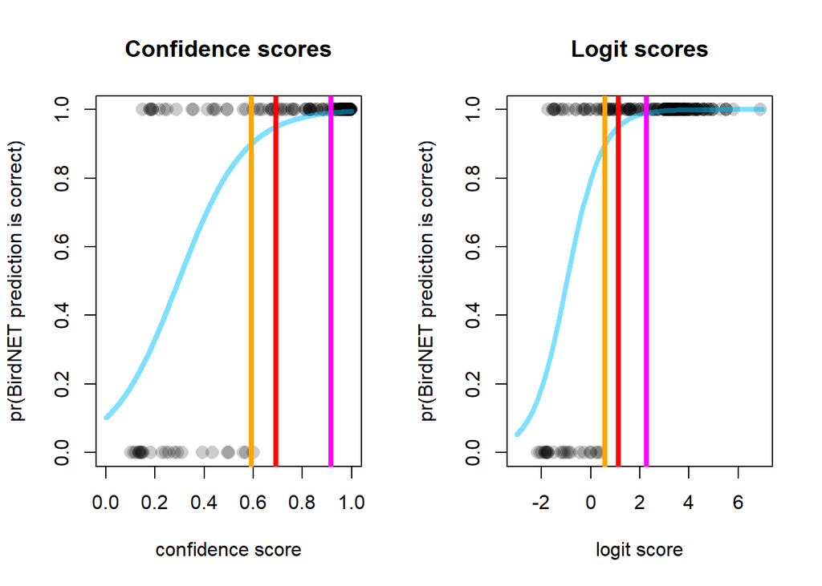

```r
  par(mfrow=c(1,2))

  plot(correct~confidence, data, main = 'Confidence scores',
       ylab = 'pr(BirdNET prediction is correct)', xlab = 'confidence score',
       xlim=range(prediction.range.conf), pch=16, cex=1.5, col=rgb(0,0,0,.2))

  lines(predictions.conf~prediction.range.conf, lwd=4, col=rgb(0,.75,1,.5))
  abline(v=cutoff90.c, col='orange', lwd=4)
  abline(v=cutoff95.c, col='red', lwd=4)
  abline(v=cutoff99.c, col='magenta', lwd=4)

  plot(correct~logit, data, main = 'Logit scores',
       ylab = 'pr(BirdNET prediction is correct)', xlab = 'logit score',
       xlim=range(prediction.range.logit), pch=16, cex=1.5, col=rgb(0,0,0,.2))

  lines(predictions.logit~prediction.range.logit, lwd=4, col=rgb(0,.75,1,.5))
  abline(v=cutoff90.l, col='orange', lwd=4)
  abline(v=cutoff95.l, col='red', lwd=4)
  abline(v=cutoff99.l, col='magenta', lwd=4)
```

## 4) Interpreting the results to select a threshold

In this case the logit scores performed better based on AIC model selection. Assuming that we use the logit score model, we now have three threshold values to pick from for creating a detection history with a 90%, 95%, or 99%, probability a detection is a true positive.

To decide which threshold to use can depend on whether it is more important in your study to include as many true positives as possible (i.e., high recall) or to strictly ensure few false positives are included (i.e., high precision). Identifying how many true positives may be removed and how many false positives may be included under each threshold can be a useful way to determine which threshold you want to use.

```r
#calculate recall and precision for each threshold
data$include.90 <- ifelse(data$logit >= cutoff90.l & data$correct == 1, "tp", NA)
data$include.90 <- ifelse(data$logit < cutoff90.l & data$correct == 1, "fn", data$include.90)
data$include.90 <- ifelse(data$logit < cutoff90.l & data$correct == 0, "tn", data$include.90)
data$include.90 <- ifelse(data$logit >= cutoff90.l & data$correct == 0, "fp", data$include.90)
r.90 <- sum(data$include.90 == "tp")/sum(data$include.90 == "tp" | data$include.90 == "fn")
p.90 <- sum(data$include.90 == "tp")/sum(data$include.90 == "tp" | data$include.90 == "fp")
#summary of FP, FN, TN, TP with 90% threshold
table(data$include.90, useNA = "ifany")
```

```
##
##  fn  tn  tp
##  24  24 152
```

```r
data$include.95 <- ifelse(data$logit >= cutoff95.l & data$correct == 1, "tp", NA)
data$include.95 <- ifelse(data$logit < cutoff95.l & data$correct == 1, "fn", data$include.95)
data$include.95 <- ifelse(data$logit < cutoff95.l & data$correct == 0, "tn", data$include.95)
data$include.95 <- ifelse(data$logit >= cutoff95.l & data$correct == 0, "fp", data$include.95)
r.95 <- sum(data$include.95 == "tp")/sum(data$include.95 == "tp" | data$include.95 == "fn")
p.95 <- sum(data$include.95 == "tp")/sum(data$include.95 == "tp" | data$include.95 == "fp")
#summary of FP, FN, TN, TP with 95% threshold
table(data$include.95, useNA = "ifany")
```

```
##
##  fn  tn  tp
##  34  24 142
```

```r
data$include.99 <- ifelse(data$logit >= cutoff99.l & data$correct == 1, "tp", NA)
data$include.99 <- ifelse(data$logit < cutoff99.l & data$correct == 1, "fn", data$include.99)
data$include.99 <- ifelse(data$logit < cutoff99.l & data$correct == 0, "tn", data$include.99)
data$include.99 <- ifelse(data$logit >= cutoff99.l & data$correct == 0, "fp", data$include.99)
r.99 <- sum(data$include.99 == "tp")/sum(data$include.99 == "tp" | data$include.99 == "fn")
p.99 <- sum(data$include.99 == "tp")/sum(data$include.99 == "tp" | data$include.99 == "fp")
#summary of FP, FN, TN, TP with 99% threshold
table(data$include.99, useNA = "ifany")
```

```
##
##  fn  tn  tp
##  55  24 121
```

```r
#combine into one dataframe
summary <- data.frame(
  threshold = c(.90, .95, .99),
  recall = c(r.90, r.95, r.99),
  precision = c(p.90, p.95, p.99)
)
summary
```

```
##   threshold    recall precision
## 1      0.90 0.8636364         1
## 2      0.95 0.8068182         1
## 3      0.99 0.6875000         1
```

From this we can see that, for this validation dataset, all thresholds resulted in equal precision: no false positives were included. However, it is important to consider that when applied to the full dataset false positives will likely be present.

In terms of recall, there was greater variability. With a 99% threshold, 31% of true positives would be removed. That may not be a big deal if detections are common, but it is worth considering in your choice of threshold.

You may want to check how different thresholds affect the number of sites that have detections or not (i.e., naive occupancy). Ideally, the thresholds will produce the same number of sites where an animal was detected at least once. It can be a good check to see if, at a given threshold, a species is detected in sites where you can be reasonably confident it should NOT be (i.e., you may be including too many false positives).

It is an open area of research to determine exactly how to translate continuous detection scores into an occupancy framework. Occupancy can be very sensitive to false positives, but false negatives may be the bigger concern in other applications (e.g., when making environmental decisions that will result in land prioritization/protection).

## 5) Creating a detection history

Let us assume we choose a 90% threshold. We would then subset the full BirdNET output to include only detections that meet or exceed the threshold value and create a site-by-visit detection history. For the purpose of this tutorial we will pretend the validation dataset is the full output

```r
#subset the data by the selected threshold
  #NOTE: this would be the full BirdNET output, not just the validation data
data.90 <- subset(data, logit >= cutoff90.l)

#extract the site name
  #NOTE: this is unique to these file names, you will have to adjust for your own file names
data.90$site <- regmatches(
  data.90$full_id,
  regexpr("G.{3}", data.90$full_id)
)
#reorder the dataframe by date
data.90$date <- regmatches(
  data.90$full_id,
  regexpr("2021.{4}", data.90$full_id)
)
data.90 <- data.90[order(data.90$date), ]

#keep only one visit per day
data.90 <- unique(data.90[, c("site", "date")])

#add value for detection
data.90$det <- 1

#format for occupancy modeling
data.occu <- reshape(data.90,
                idvar = "site",
                timevar = "date",
                direction = "wide")

#fill in non-detections with zeros
data.occu[is.na(data.occu)] <- 0
#NOTE: This assumes that ARUs were running over all recording days across all sites
  #if ARUs were not recording on a given day and site, those days need to coded as NA not zero

head(data.occu)
```

```
##     site det.20210511 det.20210512 det.20210513 det.20210514 det.20210515
## 26  G091            1            1            1            1            1
## 2   G015            0            0            0            0            0
## 143 G090            0            0            0            0            0
## 5   G089            0            0            0            0            0
## 80  G080            0            0            0            0            0
## 127 G087            0            0            0            0            0
##     det.20210516 det.20210522 det.20210525 det.20210526 det.20210528
## 26             1            1            0            0            1
## 2              0            1            0            0            0
## 143            0            0            1            1            0
## 5              0            0            0            0            0
## 80             0            0            0            0            0
## 127            0            0            0            0            0
##     det.20210604 det.20210605 det.20210606 det.20210607 det.20210608
```

[output cut: 41 more lines]

The next step, not shown here, would be to include all of the sites where no detections occurred and add them to the detection history produced above.

## Bonus: multispecies loop

If you have validated predictions for many species, probabilistic thresholds can be generated in bulk via a loop. This is a simple extension of the single-species example above. First, read in all the species-specific .csv files containing the validation results and create some basic objects that will be used for each species. This loop assumes that each species’ validation file is formatted identically to the one provided in the example above. Here, we run the loop for the Phainopepla dataset and one additional species (pija_validation.csv, Pinyon Jays).

```r
  #fill in filepath below (uses current working directory in this case)
  species.list=list.files(path='.', recursive=T, pattern='csv$', full.names = T)

  output=NULL             # create an empty object to store your outputs
  prediction.range.conf=seq(0,1,.001)
  prediction.range.logit=seq(-3,8,.1) # this is the approximate range of the logit scores

  predictions.conf=predict(conf.model, list(confidence=prediction.range.conf), type='r')
  predictions.logit=predict(logit.model, list(logit=prediction.range.logit), type='r')

  logistic.plot="yes" # do you want to plot the logistic curves?
  histogram="no"      # do you want a histogram of each species' scores?
  par(mfrow=c(2,4))
```

The most important output of the multispecies loop is a dataframe containing the logistic equation associated with each species, and a few arbitrary but commonly used probablistic cutoffs (e.g., pr(true positive) > 0.95). We have kept it basic here, but additional columns such as the AIC values of logit-based and confidence-based logistic regression models might be desired.

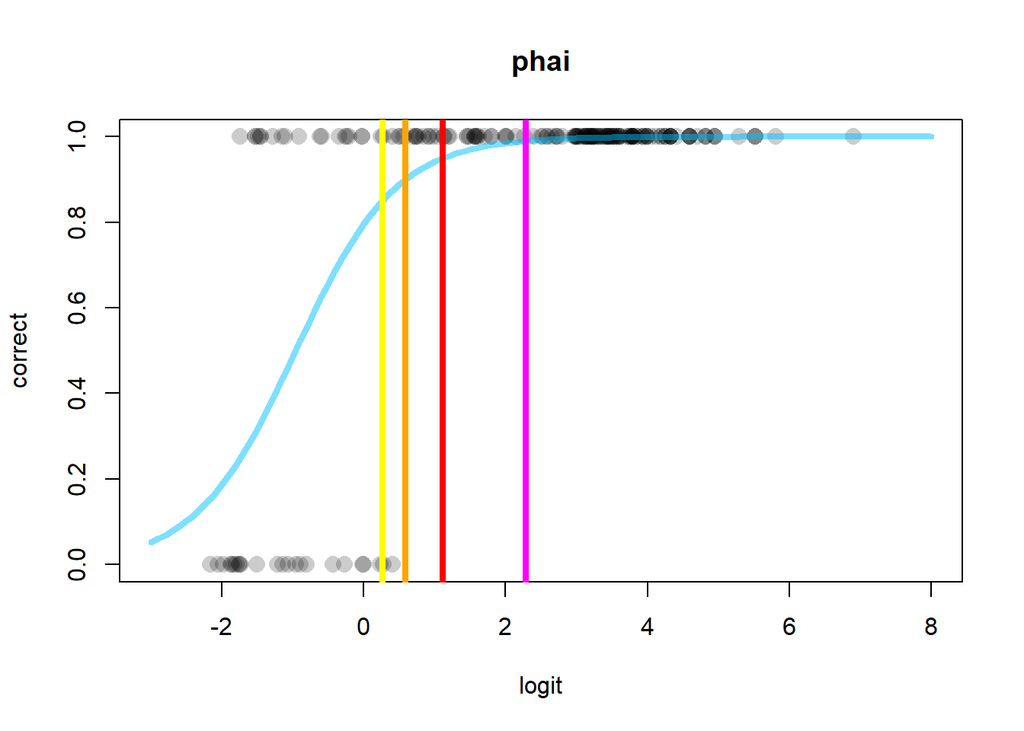

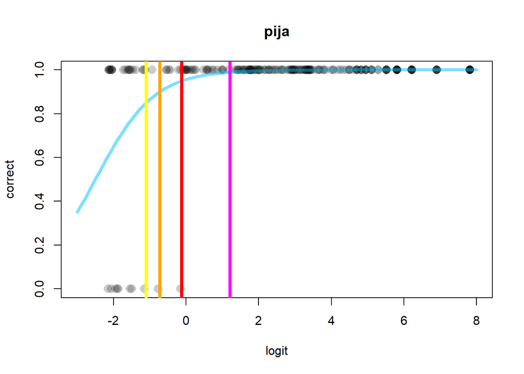

```r
for(s in 1:length(species.list)){
  dt=read.csv(species.list[s])
  dt$logit=log(dt$confidence/(1-dt$confidence))
  species=substr(species.list[s], 3, 6)
  # this assumes the files are named after their species
  # the '3' and '6' are unique to the file path and will change in your example
  output$species[s]=species

  #tmp.mod.conf=glm(correct~confidence, dt, family = 'binomial')
  tmp.mod.logit=glm(correct~logit, dt, family = 'binomial')

  #predictions.conf=predict(tmp.mod.conf, list(confidence=prediction.range.conf), type='r')
  predictions.logit=predict(tmp.mod.logit, list(logit=prediction.range.logit), type='r')

  # Note: as long as you have the logistic regression model components, you can solve for any threshold you want
  output$intercept[s]=tmp.mod.logit$coefficients[1]
  output$beta[s]=tmp.mod.logit$coefficients[2]

  # Choose your probabilistic thresholds here
  cutoff85.l=(log(.85/(1-.85))-tmp.mod.logit$coefficients[1])/tmp.mod.logit$coefficients[2]
  cutoff90.l=(log(.90/(1-.90))-tmp.mod.logit$coefficients[1])/tmp.mod.logit$coefficients[2]
  cutoff95.l=(log(.95/(1-.95))-tmp.mod.logit$coefficients[1])/tmp.mod.logit$coefficients[2]
  cutoff99.l=(log(.99/(1-.99))-tmp.mod.logit$coefficients[1])/tmp.mod.logit$coefficients[2]

  output$cutoff85[s] = cutoff85.l
  output$cutoff90[s] = cutoff90.l
  output$cutoff95[s] = cutoff95.l
  output$cutoff99[s] = cutoff99.l

  if(logistic.plot=="yes"){
    plot(correct~logit, dt, main=species,
         xlim=range(prediction.range.logit), pch=16, cex=1.5, col=rgb(0,0,0,.2))
    lines(predictions.logit~prediction.range.logit, lwd=4, col=rgb(0,.75,1,.5))
    abline(v=cutoff85.l, col='yellow', lwd=4)
    abline(v=cutoff90.l, col='orange', lwd=4)
    abline(v=cutoff95.l, col='red', lwd=4)
    abline(v=cutoff99.l, col='magenta', lwd=4)

  if(histogram=="yes"){
    hist(dt$logit, main=species,
         xlim=range(prediction.range.logit), breaks=seq(0,100,10),lty='blank', xlab='Score')
    abline(v=cutoff95.l, col=rgb(1,.5,0,.7), lwd=5)
    abline(v=cutoff99.l, col=rgb(1,0,0,.7), lwd=5)
  }

  if(s==length(species.list)){
    output=data.frame(output)
  }
  }
}
```

```r
output
```

```
##   species intercept     beta  cutoff85   cutoff90   cutoff95 cutoff99
## 1    phai  1.359262 1.416475  0.264981  0.5915830  1.1190999 2.284444
## 2    pija  3.093453 1.236831 -1.098656 -0.7246169 -0.1204807 1.214124
```

Even with 100+ species each with up to 200 validation examples, this loop can run quite quickly on a standard commericial-grade computer. Thus, you can readily adjust what is saved and what types of plots are generated. Sometimes it is useful to view the logistic plots for both confidence- and logit-score based models (and sometimes it isn’t - for multi-species applications we generally suggest choosing one score type and sticking with it for simplicity). Viewing histograms of the distribution of prediction scores can also be useful early in the process to get a sense of the overall distribution of scores for any given species.